# MEDB 5501, Module03

2026-09-08

## Topics to be covered

- What you will learn
  - The normal distribution
  - Normal probabilities and quantiles
  - Assessing normality
  - Using R to assess normality
  - Your homework

## The bell shaped curve

- Does your variation follow a bell shaped curve?
- Synonyms: normality, normal distribution
  - Values in the middle are most common
  - Frequencies taper off away from the center
  - Symmetry on either side

## Bell-shaped curve is a limit, 1

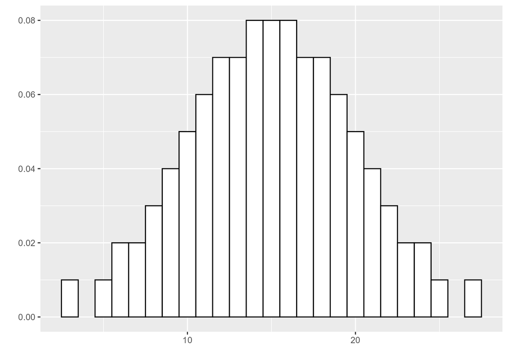

## Bell-shaped curve is a limit, 2

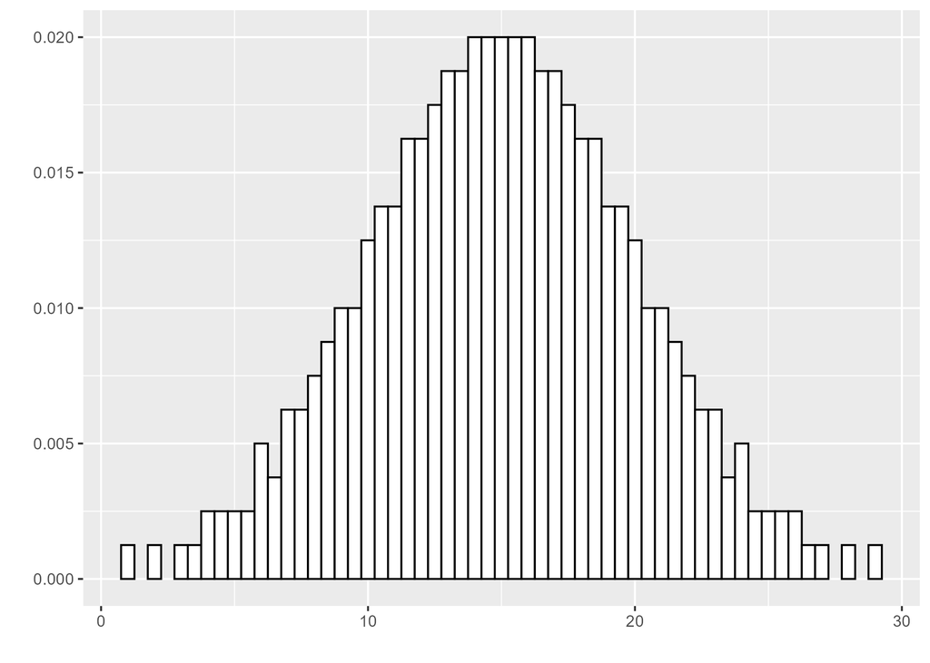

## Bell-shaped curve is a limit

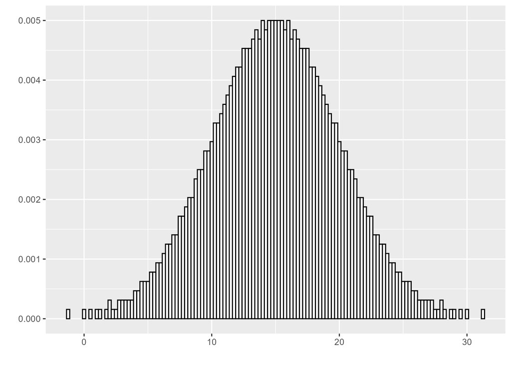

## Bell-shaped curve is a limit

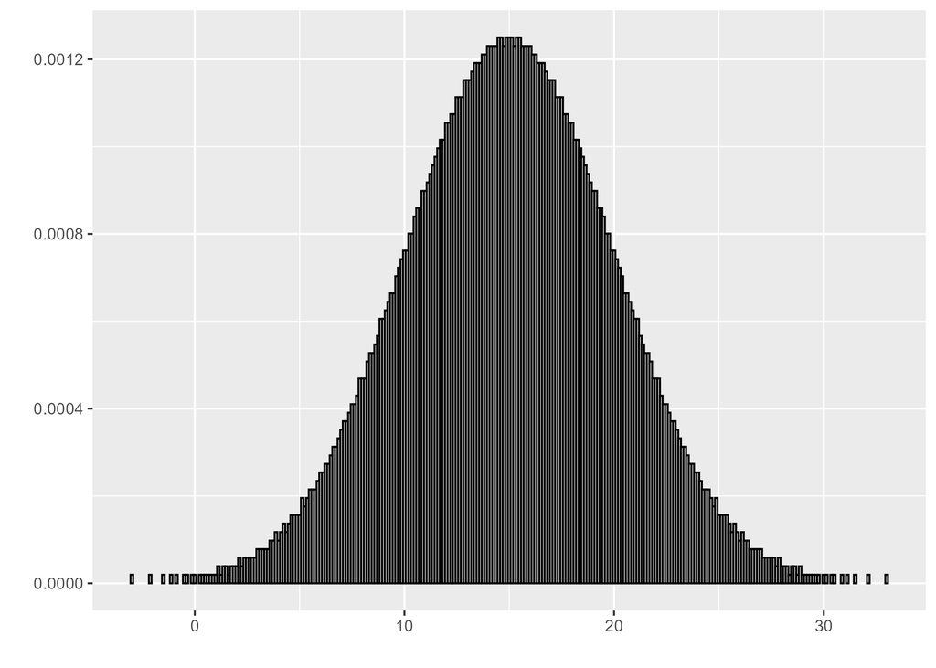

## Overview

The normal distribution is an important component of most statistical analyses. The formula for the normal distribution is quite complex,

$f(x; \mu, \sigma)=\frac{1}{\sigma\sqrt{2\pi}}e^{-\frac{(x-\mu)^2}{2\sigma^2}}$

but the shape is readily recognizable.

## Normal distribution with mu=2, sigma=1

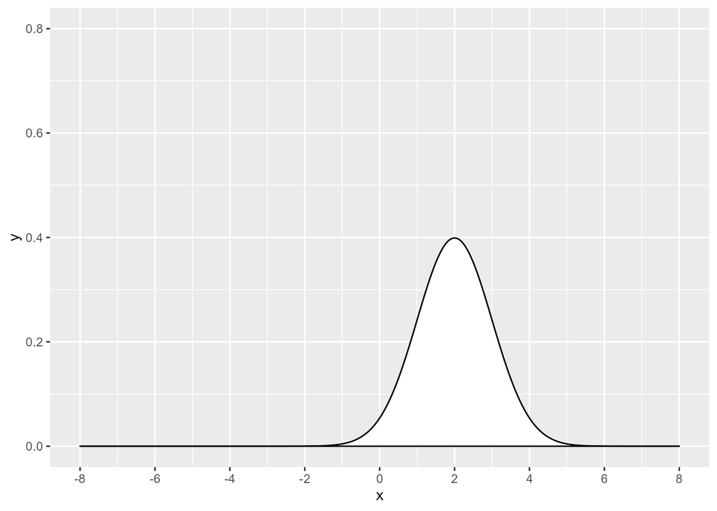

## Normal distribution with mu=-3, sigma=1

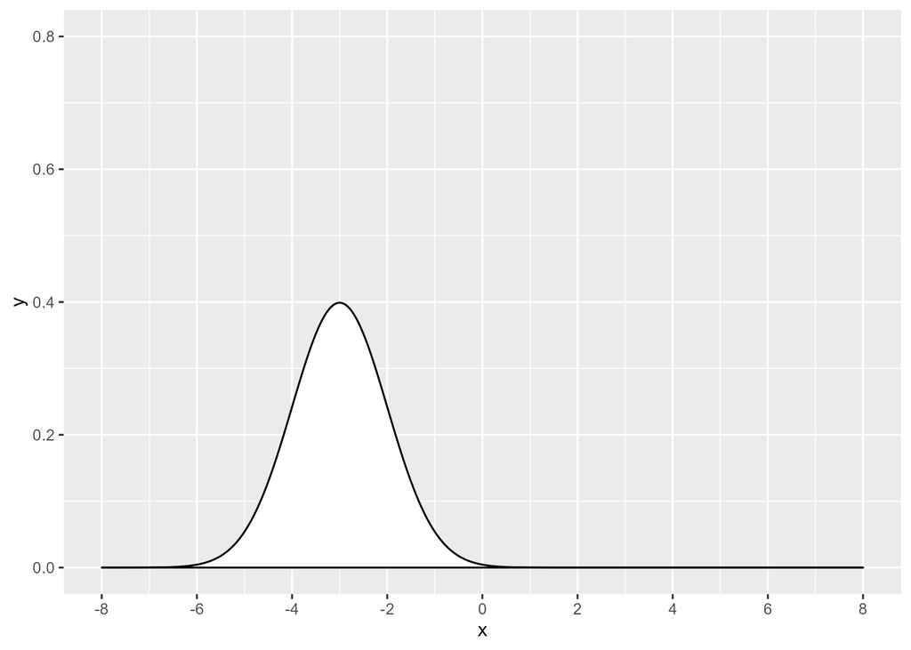

## Normal distribution with mu=1, sigma=1

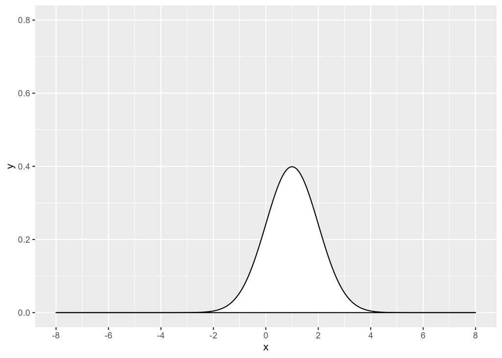

## Normal distribution with mu=1, sigma=2

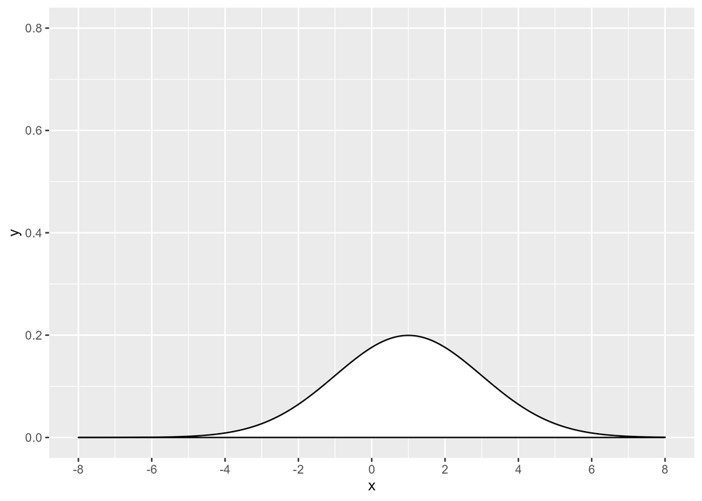

## Normal distribution with mu=1, sigma=0.5

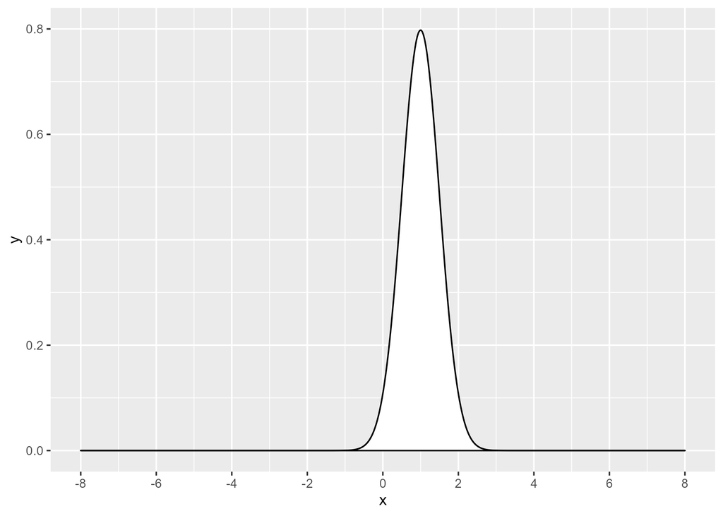

## Standard normal distribution (mu=0, sigma=1)

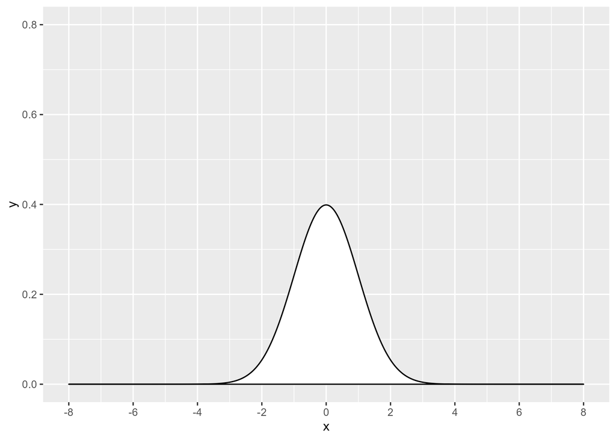

## Why concern yourself with the bell shaped curve?

- You can characterize individual observations
- You can characterize summary measures

## Break #1

- What you have learned
  - The normal distribution
- What’s coming next
  - Normal probabilities and quantiles

## The standard normal distribution, again

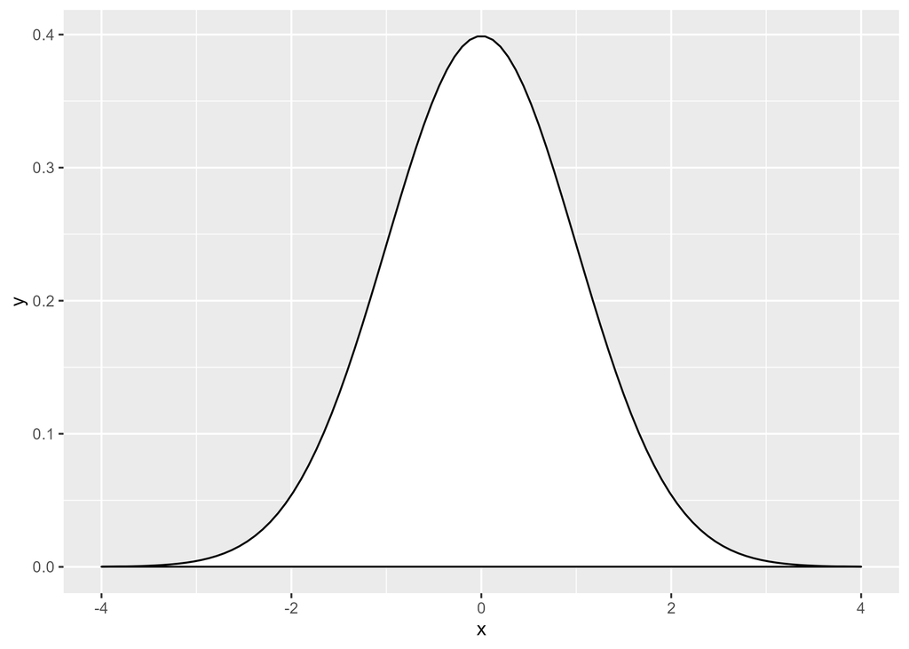

## Using calculus to compute probabilities for a normal distribution

$P[a < X < b]=\int_{a}^{b}\big(\frac{1}{\sigma\sqrt{2 \pi}}e^{-\frac{(x-\mu)^2}{2\sigma^2}}\big)dx$

## Illustrating P[Z < 1.5]

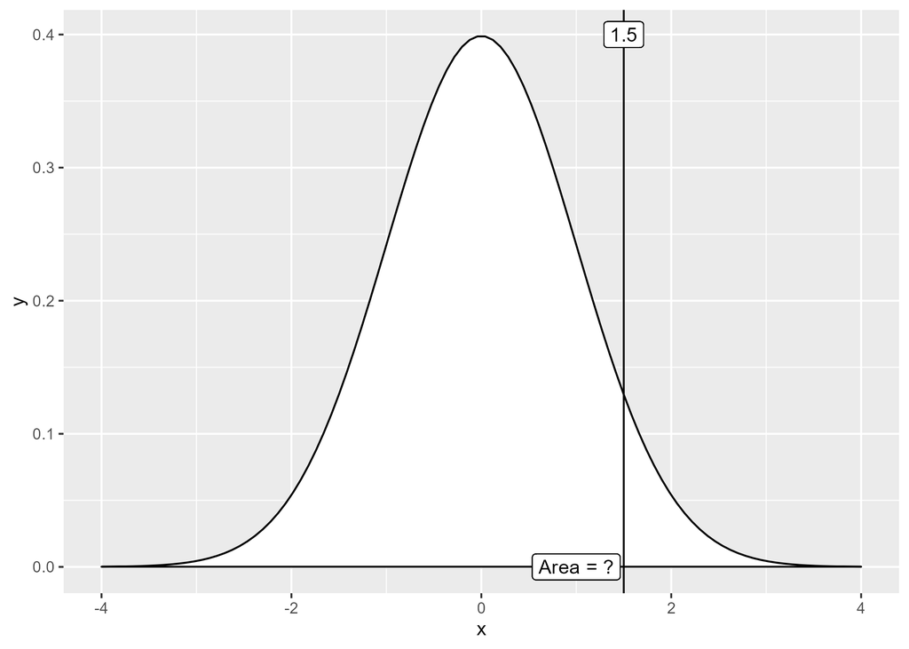

## Calculating P[Z < 1.5]

```r
pnorm(1.5)
```

```
[1] 0.9331928
```

## Illustrating P[Z < -0.5]

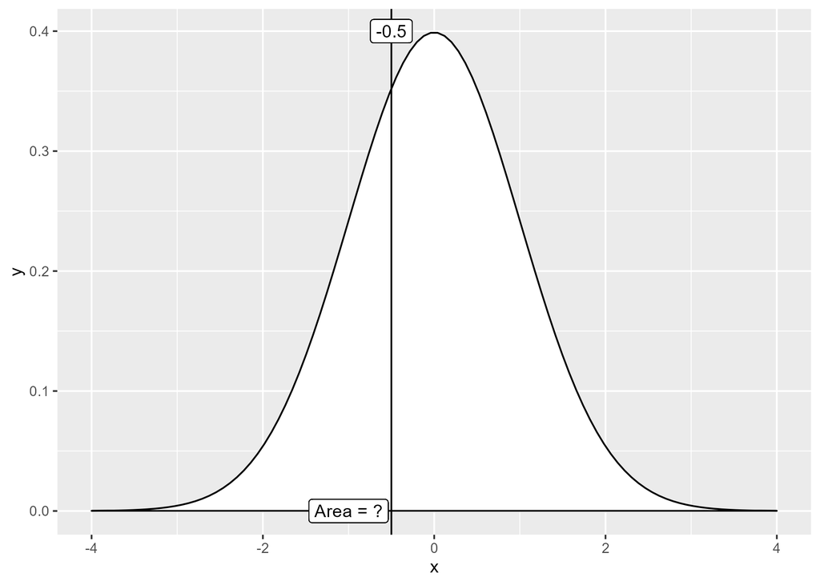

## Calculating P[Z < -0.5]

```r
pnorm(-0.5)
```

```
[1] 0.3085375
```

## Illustrating P[Z > 3]

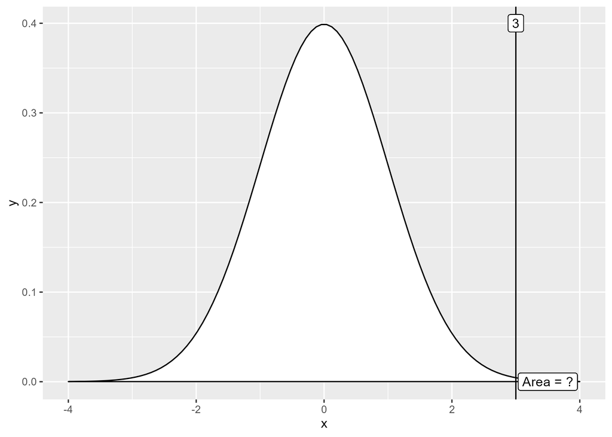

```r
1-pnorm(3)
```

```
[1] 0.001349898
```

## Illustrating P[Z > -2]

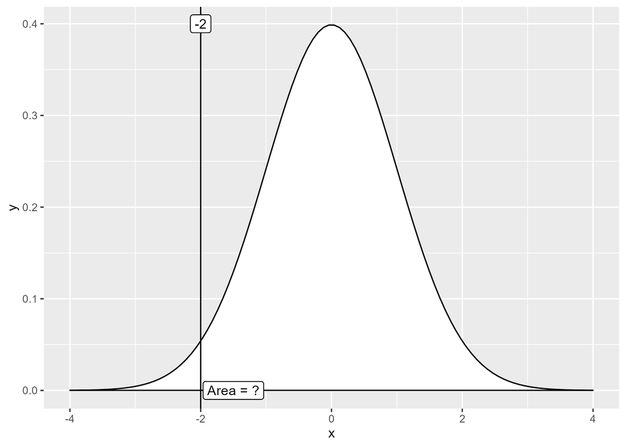

```r
1-pnorm(-2)
```

```
[1] 0.9772499
```

## Illustrating P[-2.5 < Z < 2.5]

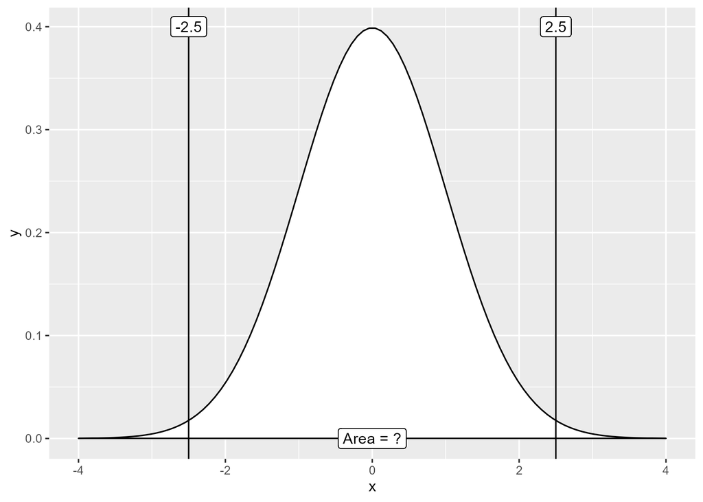

```r
pnorm(2.5)-pnorm(-2.5)
```

```
[1] 0.9875807
```

## Illustrating P[-0.5 < Z < 0.5]

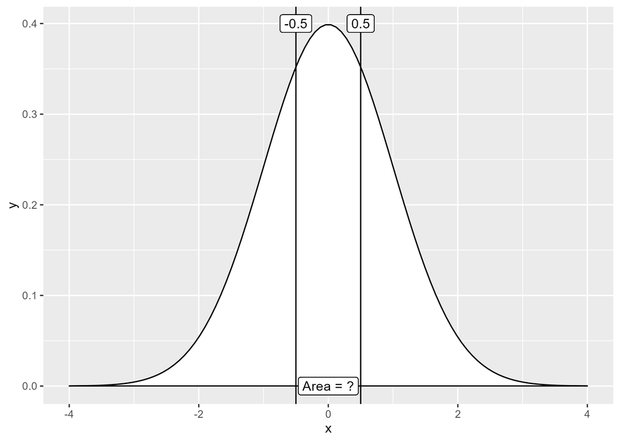

```r
pnorm(0.5)-pnorm(-0.5)
```

```
[1] 0.3829249
```

## Illustrating the 25th percentile of a standard normal

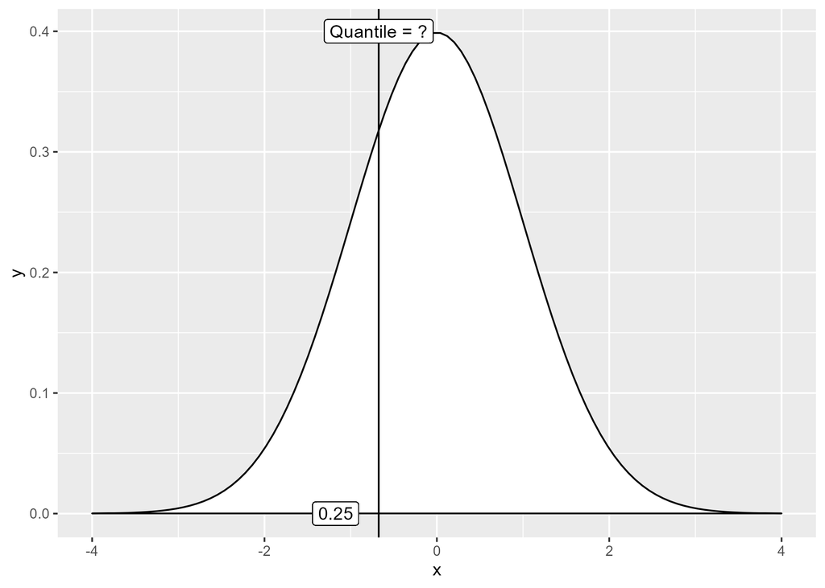

```r
qnorm(0.25)
```

```
[1] -0.6744898
```